# How Does a Bike-Share Navigate Speedy Success?

Juan Diego Avila

2023-09-01

## Introduction

Over the last few months, I have been undergoing the Google Data Analytics Professional Certificate through Coursera. This is my final capstone project for this course wherein I will be using the skills and tools I learned during the certification course in order to analyze the data of the fictional company **Cyclistic**.

To achieve my goal, I will follow the following data analysis steps: **Ask, Prepare, Process, Analyze, and Act**.

### About the Company

In 2016, Cyclistic launched a successful bike-share offering. Since then, the program has grown to a fleet of 5,824 bicycles that are geotracked and locked into a network of 692 stations across Chicago. The bikes can be unlocked from one station and returned to any other station in the system anytime.

Cyclistic offers a variety of offers including: single-ride passes, full-day passes, and annual memberships. Customers who purchase a single-ride or full-day passes are referred to as casual riders. Customers who purchase annual memberships are Cyclistic members.

### Ask

#### Guiding Question

The guiding question for this case study is: **How do annual members and casual riders use Cyclistic bikes differently?**

#### Objective

Design marketing strategies aimed at converting casual riders into annual members.

#### Our stakeholders

- **Lily Moreno:** Director of marketing, responsible for the development of campaigns and initiatives to promote the bike-share program.
- **Cyclistic executive team:** In charge of the final decision, they will decide if the recommended marketing strategy is approved.

### Prepare

#### Prepare Data

We have access to a primary [data source](https://divvy-tripdata.s3.amazonaws.com/index.html) licensed under Motivate International Inc. The dataset contains quantitative measurements collected from the bike trackers.

To conduct a thorough analysis, I retrieved data from the previous 12 months (from August 2022 to July 2023) and uploaded them to RStudio.

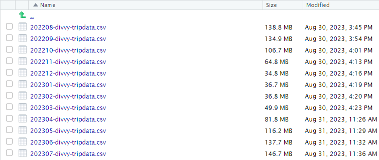

Bike Trip Data from Aug 2022 to Jul 2023

#### Data Columns

The dataset contains the following columns:

1. **ride_id** - Unique identifier of each ride
2. **rideable_type** - Type of bike used: standard two-wheel bike, reclining bike, hand tricycle, or cargo bike
3. **started_at** - Start date and time of the trip
4. **ended_at** - End date and time of the trip
5. **start_station_name** - Name of station where trip started
6. **start_station_id** - Unique identification code of the starting station
7. **end_station_name** - Name of station where trip ended
8. **end_station_id** - Unique identification code of the end station
9. **start_lat** - Latitudinal coordinate of where trip started
10. **start_lng** - Longitudinal coordinate of where trip started
11. **end_lat** - Latitudinal coordinate of where trip ended
12. **end_lng** - Longitudinal coordinate of where trip ended
13. **member_casual** - Customer type if member of casual